# Reproducing Piironen2020

Giuliano

# Generate data

The function `generate_data_01` returns a `data.frame` with y and x variables according to the data generating process from equation (1) in [Piironen (2020)](https://doi.org/10.1214/20-EJS1711). The first `p_rel` x variables should be pairwise correlated with $\rho = 0.3$ (for this example) and have marginal variances equal to $1$. The remaining x variables should be independent, standard normal random variables.

Generate the data.

```r
fake_data <- generate_data_01(N = 1e4, p = 10, rho = 0.3, p_rel = 5)
head(fake_data) %>%
  kableExtra::kable() %>%
  kableExtra::kable_styling()
```

| y | X1 | X2 | X3 | X4 | X5 | X6 | X7 | X8 | X9 | X10 |
| --- | --- | --- | --- | --- | --- | --- | --- | --- | --- | --- |
| -2.7951596 | -1.1346247 | -1.7867084 | -2.2093682 | -1.3847994 | -1.2958818 | 1.1676412 | 0.1553068 | 0.2814882 | -0.7147502 | -0.4599137 |
| -0.8325837 | -0.7143670 | -0.0529911 | -0.0982436 | 0.1093801 | 0.0396948 | 0.5718728 | 1.3977041 | -1.7194146 | 0.2214413 | -0.5315625 |
| 2.3456600 | 0.6825886 | 0.0975890 | -0.3196792 | -0.4800842 | 1.3592467 | -0.9522138 | -0.3364820 | 0.4461110 | 0.2098105 | -0.8372789 |
| 0.0120365 | -0.7611409 | -1.1413748 | -0.0941751 | -0.4486231 | -2.9424111 | -1.3692369 | -0.4445043 | -0.2415607 | 0.6811696 | 2.3886384 |
| -0.5899618 | -0.1762215 | 0.8920934 | 0.0441184 | 0.7340187 | 0.2718723 | -0.7857793 | 1.4477058 | -0.4002040 | -0.0569857 | -0.8768323 |
| 0.1271943 | -0.4258846 | -0.0878241 | -0.2527364 | 0.2269682 | -0.8843703 | 0.3276557 | -1.4308284 | -1.2603269 | -2.0624220 | -0.8269004 |

Check if correlations match.

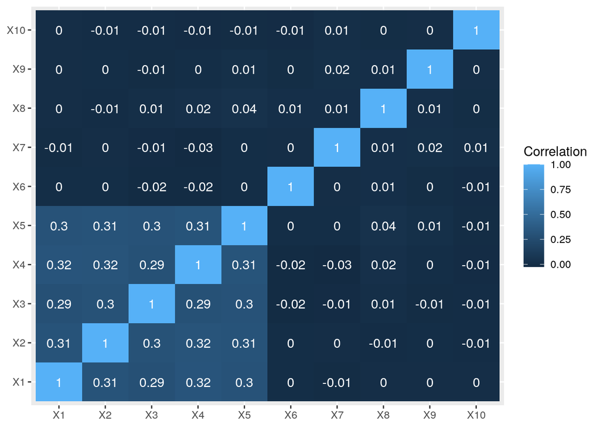

```r
fake_data %>%
  select(-y) %>%
  cor() %>% data.frame() %>% rownames_to_column('name0') %>%
  pivot_longer(col = contains('X')) %>%
  mutate(name0 = factor(name0, levels = paste0("X", 1:10)),
         name = factor(name, levels = paste0("X", 1:10))) %>%
  ggplot(aes(name0, name, fill = value)) +
  geom_tile() +
  geom_text(aes(label = round(value, 2)), color = "white") +
  labs(x = NULL, y = NULL, fill = "Correlation")
```

Check if marginal variances match.

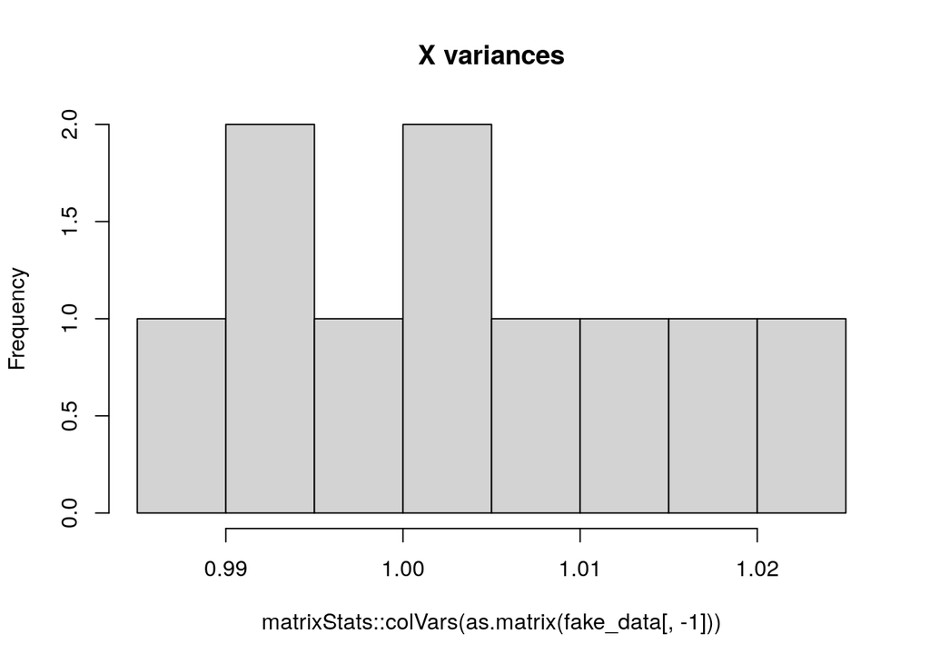

```r
hist(matrixStats::colVars(as.matrix(fake_data[,-1])),
     main = "X variances")
```

Good enough! Let’s generate a realization following the specifications in the paper.

```r
df <- generate_data_01(
  N = 50,
  p = 500,
  rho = 0.3,
  p_rel = 150
)
```

# Reference model

In the experiment from Fig 7, the authors performed Supervised Principal Component analysis and used the first 3 PCs in their regression. I will do a simplified version of their workflow using simple linear regression on the computed PCs and using $\gamma = 0.1$ as the (absolute) correlation threshold in the screening step before PCA.

```r
features_to_keep <- df %>%
  select(-y) %>%
  map_lgl(~ abs(cor(.x, df$y)) > 0.1)
pca <- prcomp(df[, features_to_keep])
new_X <- pca$x[, 1:3]
```

Out of 150 relevant features, with this screening we kept

```r
sum(paste0("X", 1:150) %in% names(features_to_keep[features_to_keep]))
```

```
## [1] 125
```

for further processing with PCA. A total of

```r
sum(features_to_keep)
```

```
## [1] 276
```

features passed the screening (out of 500).

Using `y` and `new_X`, we fit the reference model.

```r
df_reduced <- data.frame(
  y = df$y,
  new_X
)
ref_model <- lm(
  y ~ PC1 + PC2 + PC3,
  data = df_reduced
)
```

# Benefit of a reference model (LASSO only)

The authors make the claim that a reference model may be useful in selecting variables because it generates an estimate of $f$, $f_*$, which hopefully increases the discrimination between ‘bad’ and ‘good’ features. Let’s see if that holds with LASSO alone.

Fit the models

```r
# install.packages('glmnet')
library(glmnet)
X <- as.matrix(df[, -1])
y <- df[, 1]
y_ref <- predict(ref_model)
fit_no_ref <- cv.glmnet(X, y)
fit_ref <- cv.glmnet(X, y_ref)
```

Generate large test set for external validation.

```r
test_data <- generate_data_01(
  N = 1e5,
  p = 500,
  rho = 0.3,
  p_rel = 150
)
```

Compute performance for the model without reference model.

```r
preds_no_ref <- predict(fit_no_ref,
                        newx = as.matrix(test_data[, -1]),
                        s = "lambda.1se")
rmse_no_ref <- rmse(preds_no_ref[, 1], test_data$y) %>% round(2)
str_glue("RMSE without reference: {rmse_no_ref}")
```

```
## RMSE without reference: 1.42
```

With the reference model.

```r
preds_ref <- predict(fit_ref,
                     newx = as.matrix(test_data[, -1]),
                     s = "lambda.1se")
rmse_ref <- rmse(preds_ref[, 1], test_data$y) %>% round(2)
str_glue("RMSE with reference: {rmse_ref}")
```

```
## RMSE with reference: 1.18
```

The model with reference seems better. Let’s look at the regularization paths.

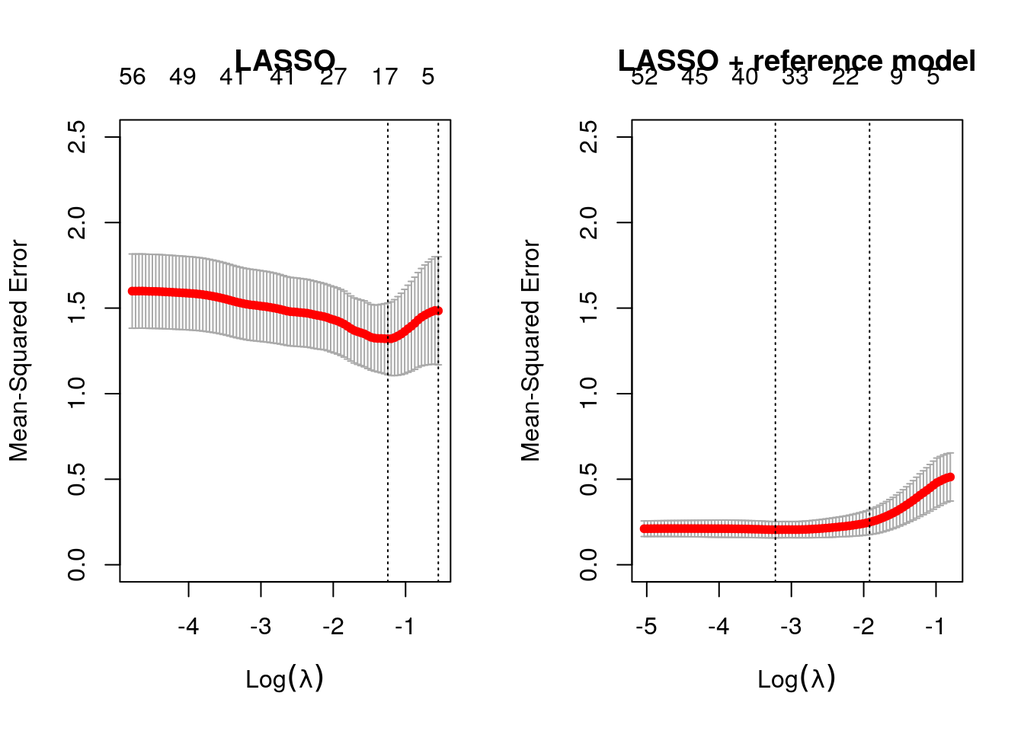

```r
par(mfrow = c(1,2))
plot(fit_no_ref, ylim = c(0,2.5), main = "LASSO")
plot(fit_ref, ylim = c(0,2.5), main = "LASSO + reference model")
```

This thing seems to work! Let’s encapsulate everything we’ve done inside a function and then repeat this simulation multiple times.

```r
simulate_reference_model_effect <- function(
  N = 50,
  p = 500,
  rho = 0.3,
  p_rel = 150,
  gamma = 0.1,
  PCs_to_keep = 3,
  sim = NULL,
  test_data = NULL,
  .verbose = FALSE
) {

  if (!is.null(sim) & isTRUE(.verbose)) {
    print(str_glue("Simulation: {sim}"))
  }

  # generate observations
  df <- generate_data_01(N = N, p = p, rho = rho, p_rel = p_rel)

  # screen features + SPCA
  features_to_keep <- df %>%
    select(-y) %>%
    map_lgl(~ abs(cor(.x, df$y)) > gamma)
  df_subset <- df[, features_to_keep]
  pca <- prcomp(df_subset)
  new_X <- pca$x[, 1:PCs_to_keep]

  # fit reference model
  df_reduced <- data.frame(y = df$y, new_X)
  ref_model <- lm(y ~ ., data = df_reduced)

  # fit LASSO models
  X <- as.matrix(df[, -1])
  y <- df[, 1]
  y_ref <- predict(ref_model)
  fit_no_ref <- glmnet::cv.glmnet(X, y)
  fit_ref <- glmnet::cv.glmnet(X, y_ref)

  # generate test data
  if (is.null(test_data)) {
    test_data <- generate_data_01(
      N = 5e4,
      p = p,
      rho = rho,
      p_rel = p_rel
    )
  }
  # test predictions without reference
  preds_no_ref <- predict(fit_no_ref,
                          newx = as.matrix(test_data[, -1]),
                          s = "lambda.1se")
  rmse_no_ref <- rmse(preds_no_ref[, 1], test_data$y)

  # test predictions with reference
  preds_ref <- predict(fit_ref,
                       newx = as.matrix(test_data[, -1]),
                       s = "lambda.1se")
  rmse_ref <- rmse(preds_ref[, 1], test_data$y)

  # test predictions of reference model
  new_X_test <- predict(pca, newdata = test_data[, features_to_keep])
  preds_ref_model <- predict(ref_model, newdata =  data.frame(new_X_test))
  rmse_ref_model <- rmse(preds_ref_model, test_data$y)

  # get sizes of each model (number of variables selected)
  b_no_ref <- coef(fit_no_ref, s = 'lambda.1se') %>% as.matrix()
  b_ref <- coef(fit_ref, s = 'lambda.1se') %>% as.matrix()
  size_no_ref <- sum(abs(b_no_ref) > 0 )
  size_ref <- sum(abs(b_ref) > 0 )

  # get proportion of (in) correctly selected variables
  kept_no_ref <- rownames(b_no_ref)[abs(b_no_ref) > 0][-1]  # exclude intercept
  kept_ref <- rownames(b_ref)[abs(b_ref) > 0][-1]
  rel_features <- paste0("X", 1:p_rel)
  tp_no_ref <- sum(rel_features %in% kept_no_ref)
  tp_ref <- sum(rel_features %in% kept_ref)
  fp_no_ref <- sum(!(kept_no_ref %in% rel_features))
  fp_ref <- sum(!(kept_ref %in% rel_features))

  return(data.frame(
    rmse_no_ref, rmse_ref, rmse_ref_model,
    size_no_ref, size_ref,
    tp_no_ref, tp_ref,
    fp_no_ref, fp_ref
  ))
}
```

Let’s simulate 100 realizations of the experiment.

```r
set.seed(123)
test_ix <- sample(1:nrow(test_data), 1e4)
simulation <- map(
  1:100,
  ~ simulate_reference_model_effect(
    sim = .x,
    test_data = test_data[test_ix,]
  )
) %>%
  bind_rows(.id = "sim")
```

Plot the results.

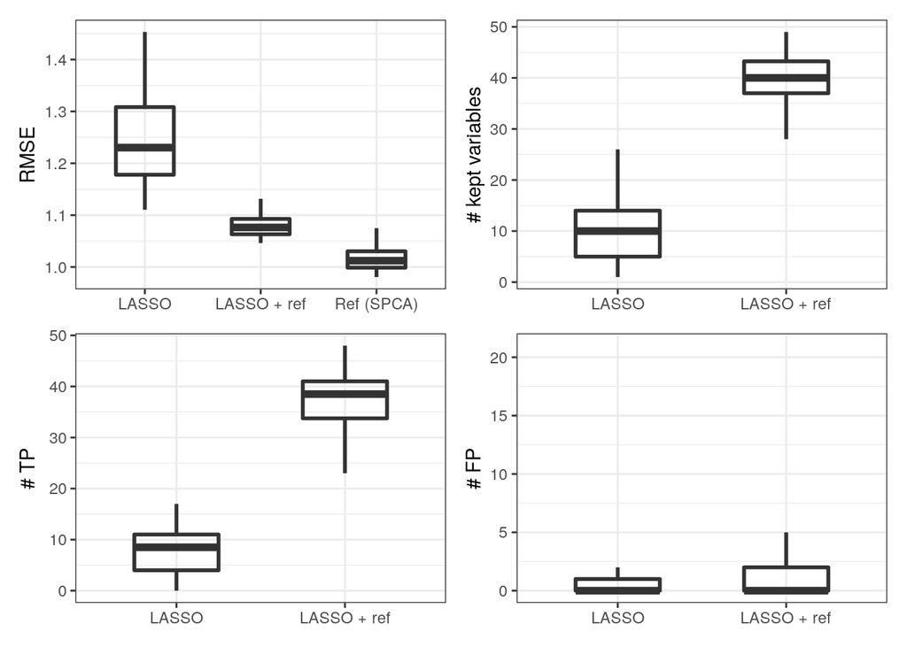

```r
library(patchwork)
theme_set(theme_bw())

p1 <- simulation %>%
  pivot_longer(cols = contains('rmse')) %>%
  mutate(
    name = case_when(
      name == "rmse_ref" ~ "LASSO + ref",
      name == "rmse_no_ref" ~"LASSO",
      T ~ "Ref (SPCA)"
    )
  ) %>%
  ggplot(aes(name, value)) +
  geom_boxplot(alpha = 0, width = .5, lwd = 1) +
  labs(x = NULL, y = "RMSE")
p2 <- simulation %>%
  pivot_longer(cols = contains('size')) %>%
  mutate(
    name = case_when(
      name == "size_ref" ~ "LASSO + ref",
      name == "size_no_ref" ~"LASSO",
      T ~ "Ref (SPCA)"
    )
  ) %>%
  ggplot(aes(name, value)) +
  geom_boxplot(alpha = 0, width = .5, lwd = 1) +
  labs(x = NULL, y = "# kept variables")
p3 <- simulation %>%
  pivot_longer(cols = contains('tp')) %>%
  mutate(
    name = case_when(
      name == "tp_ref" ~ "LASSO + ref",
      name == "tp_no_ref" ~"LASSO",
      T ~ "Ref (SPCA)"
    )
  ) %>%
  ggplot(aes(name, value)) +
  geom_boxplot(alpha = 0, width = .5, lwd = 1) +
  labs(x = NULL, y = "# TP")
p4 <- simulation %>%
  pivot_longer(cols = contains('fp')) %>%
  mutate(
    name = case_when(
      name == "fp_ref" ~ "LASSO + ref",
      name == "fp_no_ref" ~"LASSO",
      T ~ "Ref (SPCA)"
    )
  ) %>%
  ggplot(aes(name, value)) +
  geom_boxplot(alpha = 0, width = .5, lwd = 1) +
  labs(x = NULL, y = "# FP")

(p1 + p2) / (p3 + p4)
```

Showing the observed values for each simulation.

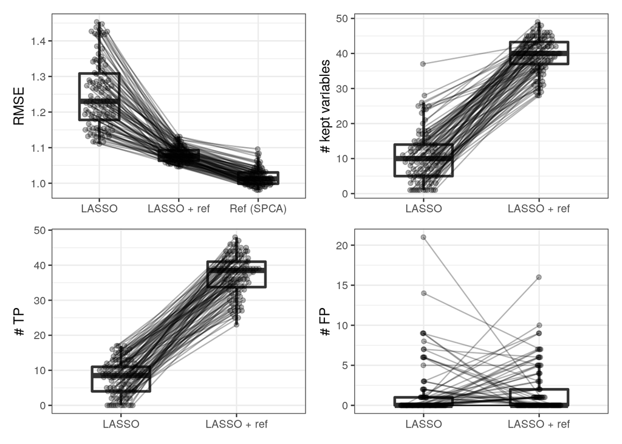

```r
f <- function(p) {
  p +
    geom_line(
      aes(group = sim),
      alpha = .3,
      position = ggbeeswarm::position_quasirandom(width = .2)
    ) +
    geom_point(
      alpha = .3,
      position = ggbeeswarm::position_quasirandom(width = .2)
    )
}

(f(p1) + f(p2)) / (f(p3) + f(p4))
```

questions: what is ref model overfits? what if ref model is overparameterized?

Cool! Let’s scale up and test varying sample sizes and $\rho$ values.